# StockResearch

Gabriel Foix

2020-09-30

Buy Quality at the a good momentum. Get rid of the fishy stocks on time. That's all.

### Factor 1: Quality

1. Healthy debts: A company shoud generate cash in order to repay its debt. The **Free Cash Flow to Debt** ratio is a good indicator of how quick a company pays back its debt. The lower this ratio the better.

FCF2D = $\frac{Debt}{Free Cash Flow}$

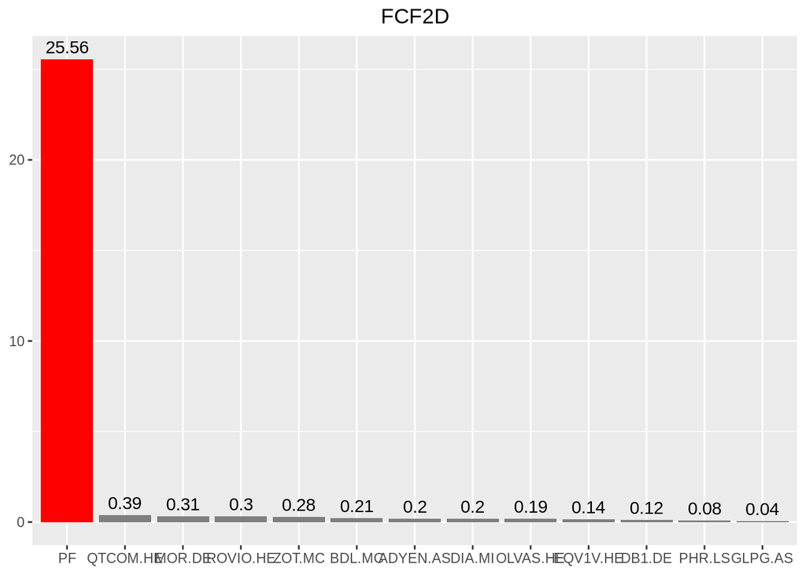

2. Profitability: ROA

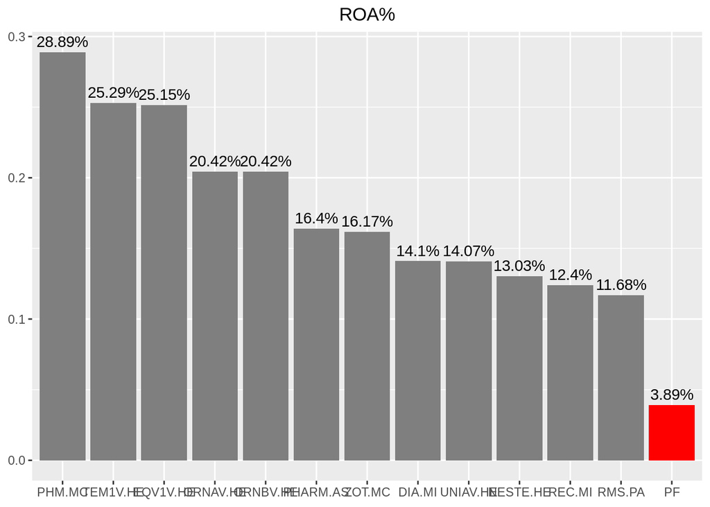

3. High Margin: We look for companies that generate free cash flow compare to its price. The **Free Cash Flow to Entreprise Value** ratio tells us how many years of cash flow would be needed to the return the 100% of the investment. Again, the lower, the better. Values bellow 1 would mean "free lunch".

FCF2EV = $\frac{EV}{Free Cash Flow}$

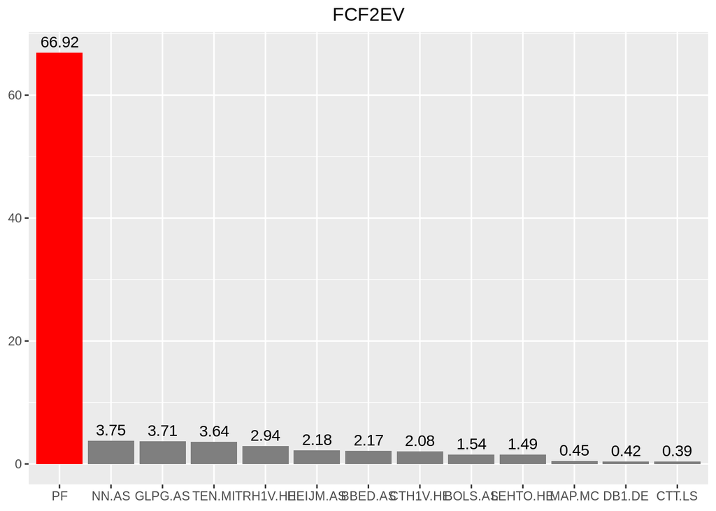

### Factor 2: Momentum

Don't hold onto a stock simply because it is high quality. So called quality stocks have cycles too. Stan Weinstein (page 177)

Generic Intermediate-Term Momentum Based on Gray-Vogel (page 80)

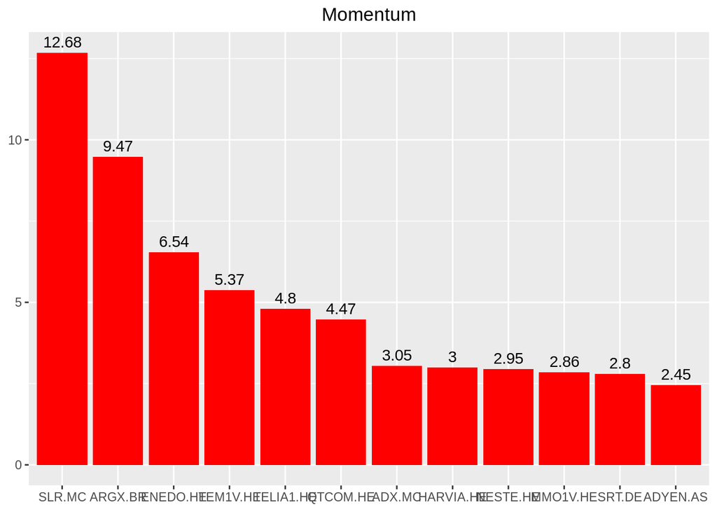

### Factor 3: Timing Signal

Sell Signal - Pr < 1% SMA 30 weeks and slope negative (< -0.2) Buy Signal - 109% * SMA30 < Pr > SMA 30 and slope positive (> 0.2) Hold Signal - Neither Buy nor Sell

### Summary

Summary

| Ticker | Signal | Quality | Momentum | Final_rank |
| --- | --- | --- | --- | --- |
| NESTE.HE | HOLD | 459.0 | 452 | 460.0 |
| TELIA1.HE | HOLD | 439.0 | 456 | 459.0 |
| SLR.MC | HOLD | 424.0 | 460 | 458.0 |
| RACE.MI | BUY | 456.0 | 406 | 457.0 |
| ROVI.MC | HOLD | 455.0 | 402 | 456.0 |
| TEG.DE | HOLD | 431.0 | 425 | 455.0 |
| PHM.MC | HOLD | 417.0 | 430 | 454.0 |
| YEINT.HE | HOLD | 445.0 | 401 | 453.0 |
| DIGIA.HE | HOLD | 404.5 | 440 | 452.0 |
| ACG1V.HE | HOLD | 426.0 | 411 | 451.0 |
| EDP.LS | HOLD | 441.0 | 395 | 450.0 |
| GXI.DE | HOLD | 440.0 | 385 | 449.0 |
| FBK.MI | BUY | 409.0 | 414 | 448.0 |
| EVLI.HE | HOLD | 423.0 | 398 | 447.0 |
| ORDI.AS | HOLD | 425.0 | 394 | 446.0 |
| ANA.MC | HOLD | 420.0 | 390 | 445.0 |
| TRN.MI | HOLD | 449.0 | 360 | 443.5 |
| VALMT.HE | HOLD | 422.0 | 387 | 443.5 |
| UNIAV.HE | HOLD | 460.0 | 340 | 442.0 |
| IG.MI | BUY | 452.0 | 339 | 441.0 |
| REC.MI | BUY | 458.0 | 330 | 440.0 |
| GLPG.AS | SELL | 438.0 | 345 | 439.0 |
| MMO1V.HE | HOLD | 331.0 | 451 | 438.0 |
| US.MI | BUY | 404.5 | 377 | 437.0 |
| FORTUM.HE | BUY | 421.0 | 357 | 436.0 |
| EQV1V.HE | HOLD | 381.0 | 396 | 435.0 |
| EURN.BR | HOLD | 412.0 | 363 | 434.0 |
| SRG.MI | BUY | 448.0 | 326 | 433.0 |
| NEDAP.AS | HOLD | 410.0 | 362 | 432.0 |
| HONBS.HE | HOLD | 454.0 | 317 | 431.0 |

[output cut: 430 more lines]